# NFL 2020 Week 19

MAJ Daniel Baller

8/27/2019

## Instructor Group Predictions

This Week's Predictions

Week 19

| Game | Prediction | Winner | Correct | Correct Votes | Correct Percent |
| --- | --- | --- | --- | --- | --- |
| 1 | Green Bay Packers | Green Bay Packers | Yes | 14 | 0.9333 |
| 2 | Buffalo Bills | Buffalo Bills | Yes | 9 | 0.6000 |
| 3 | Kansas City Chiefs | Kansas City Chiefs | Yes | 13 | 0.8667 |
| 4 | New Orleans Saints | Tampa Bay Buccaneers | No | 7 | 0.4667 |

Our win percentage for the week is 0.75

Our season win percentage so far is 0.6718

Games picked this season 262

Correct Games this season 176

predictions this week

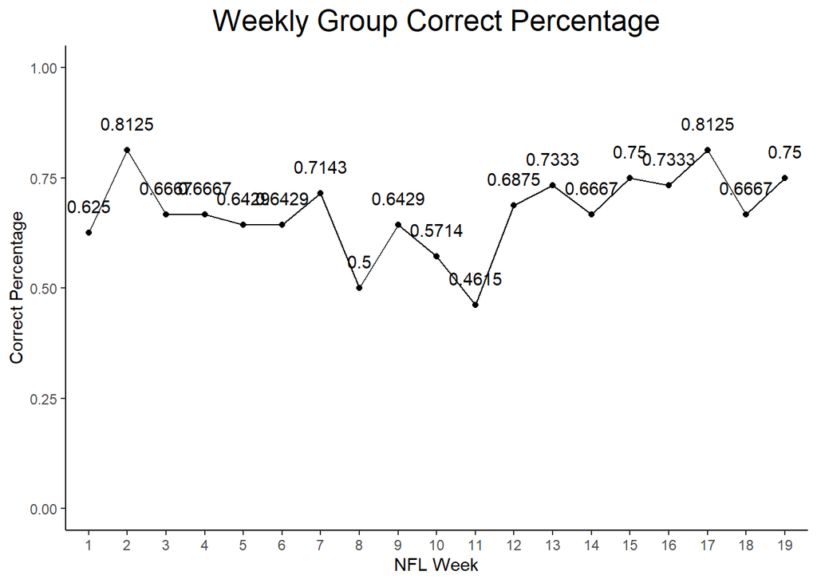

## Individual Predictions

Individual Results

Week 19

Name

Weekly # Correct

Percent

Weeks Picked

Season Percent

Adj Season Percent

Season Trend

Week 1

Week 2

Week 3

Week 4

Week 5

Week 6

Week 7

Week 8

Week 9

Week 10

Week 11

Week 12

Week 13

Week 14

Week 15

Week 16

Week 17

Week 18

Week 19

James Pleuss

9

12

10

12

7

8

10

9

9

10

7

10

12

12

11

9

NA

4

4

1.00

18

0.6707

0.6354

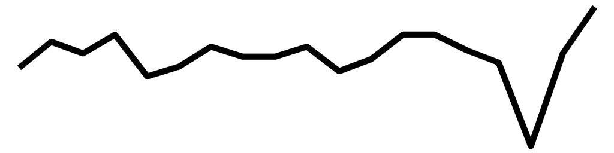

Michael Prokos

9

12

9

8

11

10

9

7

9

9

7

10

11

12

12

9

NA

4

4

1.00

18

0.6585

0.6238

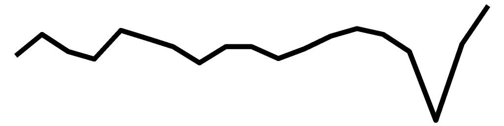

Kevin Cummiskey

13

11

9

9

10

7

9

5

10

9

7

12

10

10

12

10

14

4

3

0.75

19

0.6641

0.6641

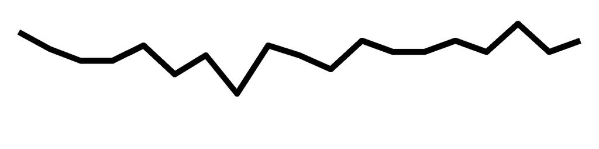

Gregory Minetos

9

14

10

12

8

8

12

7

10

7

7

11

9

9

12

8

13

4

3

0.75

19

0.6603

0.6603

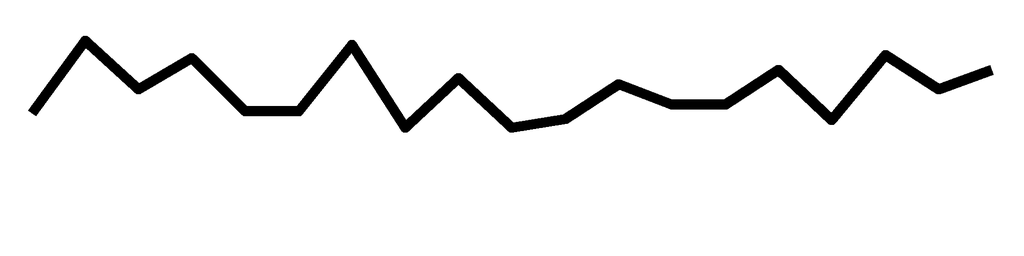

Gabriel Costa

9

12

6

9

10

7

9

7

10

10

9

NA

11

8

9

10

13

3

3

0.75

18

0.6301

0.5969

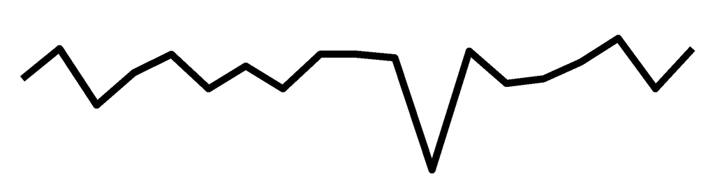

Frank Czerniakowski

7

13

10

9

8

6

9

6

11

5

9

11

9

12

NA

10

13

3

3

0.75

18

0.6260

0.5931

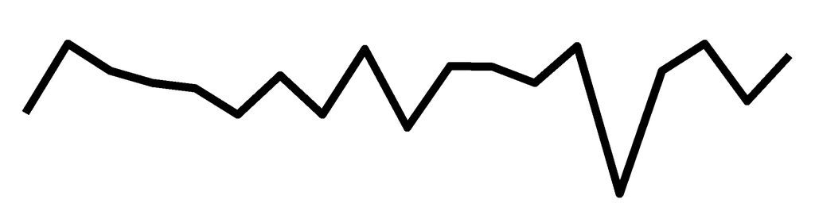

Blake Schwartz

10

9

10

10

10

9

9

6

5

8

7

9

11

10

11

11

13

3

3

0.75

19

0.6260

0.6260

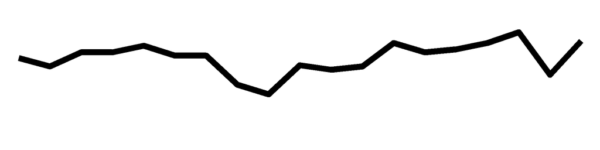

John Kearby

9

11

6

9

9

8

12

6

9

10

6

10

11

9

11

10

NA

5

3

0.75

18

0.6260

0.5931

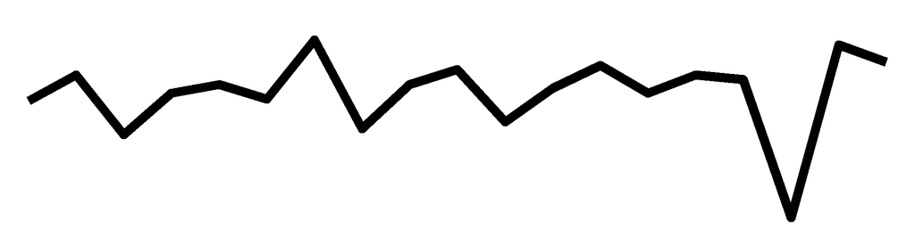

Welvin Lucero

9

11

9

10

NA

NA

11

8

NA

8

5

NA

NA

10

NA

NA

NA

NA

3

0.75

10

0.6176

0.3251

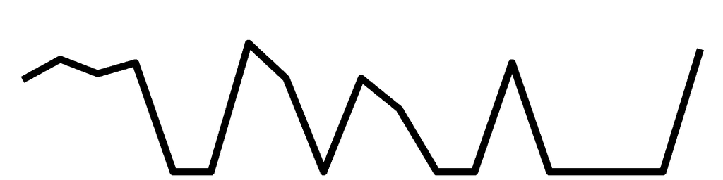

Eric Swenson

4

8

10

9

9

8

9

8

7

8

8

10

11

9

12

11

13

3

3

0.75

19

0.6107

0.6107

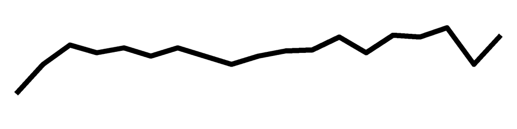

Tina Hartley

9

11

10

8

8

9

9

7

3

8

6

10

9

9

12

10

14

3

3

0.75

19

0.6031

0.6031

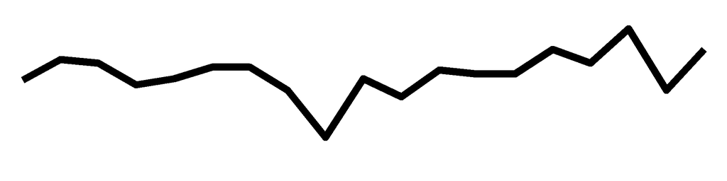

James Starling

15

12

9

12

10

NA

11

8

10

10

6

11

11

7

10

14

NA

5

2

0.50

17

0.7026

0.6286

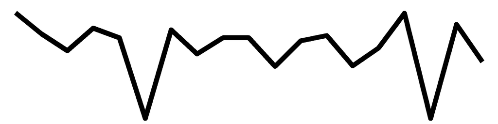

Daniel Baller

11

10

10

9

9

5

8

9

11

10

8

11

11

11

10

11

12

3

2

0.50

19

0.6527

0.6527

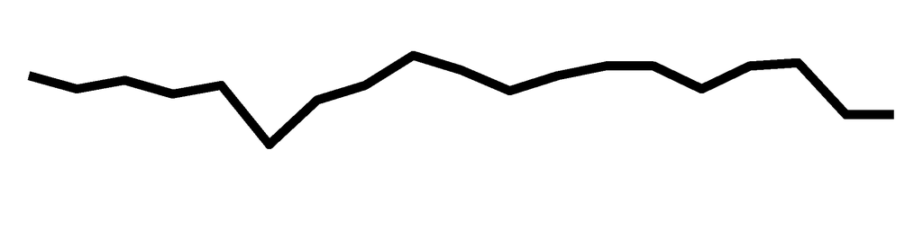

Nicholas Reisweber

9

10

10

8

10

7

8

8

10

9

6

14

9

8

9

11

NA

4

2

0.50

18

0.6179

0.5854

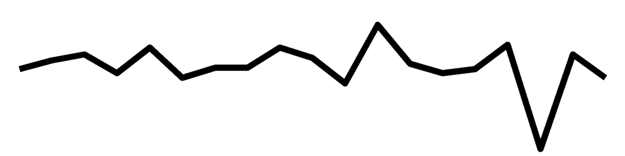

Kevin Quigley

8

8

9

10

10

8

8

6

8

7

9

10

NA

NA

11

9

NA

3

2

0.50

16

0.5833

0.4912

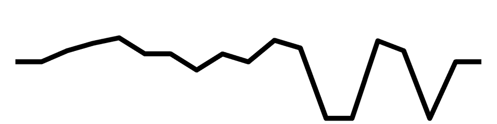

Daniel Richardson

13

11

10

10

8

NA

8

NA

NA

NA

NA

NA

NA

NA

NA

NA

NA

NA

NA

0.00

6

0.6667

0.2105

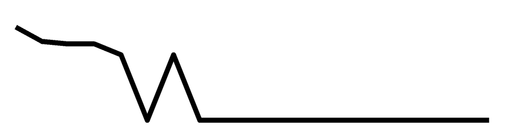

Shane Clark

10

14

9

9

9

9

10

NA

11

7

7

12

10

11

NA

NA

10

2

NA

0.00

15

0.6573

0.5189

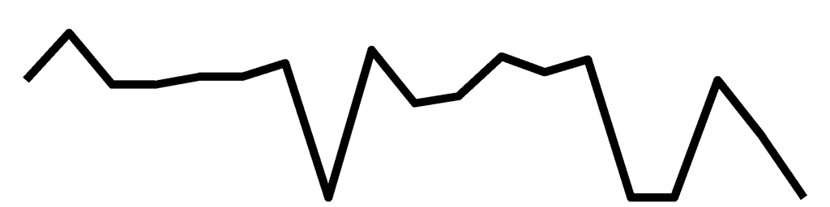

Josephine Cammack

9

11

12

10

9

9

11

7

6

8

NA

9

12

11

12

NA

12

3

NA

0.00

16

0.6565

0.5528

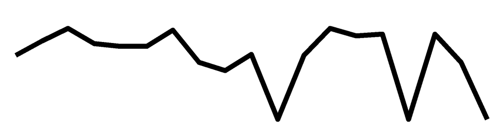

Margaret Wieczorek

11

14

9

9

8

NA

10

8

9

8

7

8

11

11

12

NA

NA

NA

NA

0.00

14

0.6522

0.4806

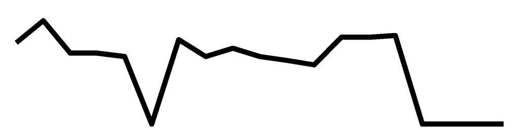

Travis Russell

11

8

8

11

10

10

10

8

NA

NA

7

NA

NA

NA

NA

NA

NA

NA

NA

0.00

9

0.6336

0.3001

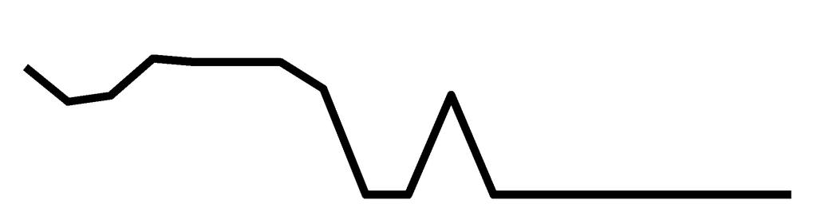

Timothy Moore

10

11

8

9

7

9

7

7

7

NA

NA

NA

9

10

8

NA

NA

4

NA

0.00

13

0.5761

0.3942

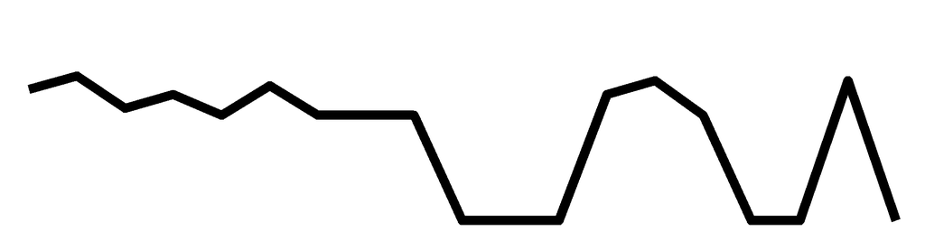

Andrew Lee

9

10

8

NA

NA

NA

NA

NA

NA

NA

NA

NA

NA

NA

NA

NA

NA

NA

NA

0.00

3

0.5745

0.0907

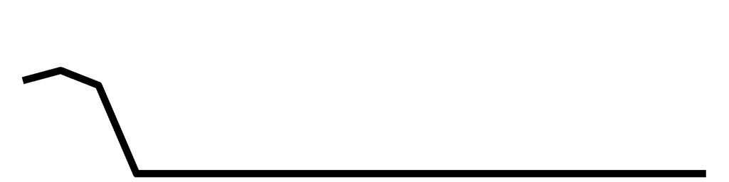

Congrats James Pleuss for having the best picks this week, with a correct percentage of 1, Congrats Michael Prokos for having the best picks this week, with a correct percentage of 1

| Name | Week 1 | Week 2 | Week 3 | Week 4 | Week 5 | Week 6 | Week 7 | Week 8 | Week 9 | Week 10 | Week 11 | Week 12 | Week 13 | Week 14 | Week 15 | Week 16 | Week 17 | Week 18 | Week 19 | Percent | Weeks Picked | Season Percent | Adj Season Percent | Season Trend |
| --- | --- | --- | --- | --- | --- | --- | --- | --- | --- | --- | --- | --- | --- | --- | --- | --- | --- | --- | --- | --- | --- | --- | --- | --- |
| James Pleuss | 9 | 12 | 10 | 12 | 7 | 8 | 10 | 9 | 9 | 10 | 7 | 10 | 12 | 12 | 11 | 9 | NA | 4 | 4 | 1.00 | 18 | 0.6707 | 0.6354 |  |
| Michael Prokos | 9 | 12 | 9 | 8 | 11 | 10 | 9 | 7 | 9 | 9 | 7 | 10 | 11 | 12 | 12 | 9 | NA | 4 | 4 | 1.00 | 18 | 0.6585 | 0.6238 |  |
| Kevin Cummiskey | 13 | 11 | 9 | 9 | 10 | 7 | 9 | 5 | 10 | 9 | 7 | 12 | 10 | 10 | 12 | 10 | 14 | 4 | 3 | 0.75 | 19 | 0.6641 | 0.6641 |  |
| Gregory Minetos | 9 | 14 | 10 | 12 | 8 | 8 | 12 | 7 | 10 | 7 | 7 | 11 | 9 | 9 | 12 | 8 | 13 | 4 | 3 | 0.75 | 19 | 0.6603 | 0.6603 |  |
| Gabriel Costa | 9 | 12 | 6 | 9 | 10 | 7 | 9 | 7 | 10 | 10 | 9 | NA | 11 | 8 | 9 | 10 | 13 | 3 | 3 | 0.75 | 18 | 0.6301 | 0.5969 |  |
| Frank Czerniakowski | 7 | 13 | 10 | 9 | 8 | 6 | 9 | 6 | 11 | 5 | 9 | 11 | 9 | 12 | NA | 10 | 13 | 3 | 3 | 0.75 | 18 | 0.626 | 0.5931 |  |
| Blake Schwartz | 10 | 9 | 10 | 10 | 10 | 9 | 9 | 6 | 5 | 8 | 7 | 9 | 11 | 10 | 11 | 11 | 13 | 3 | 3 | 0.75 | 19 | 0.626 | 0.626 |  |
| John Kearby | 9 | 11 | 6 | 9 | 9 | 8 | 12 | 6 | 9 | 10 | 6 | 10 | 11 | 9 | 11 | 10 | NA | 5 | 3 | 0.75 | 18 | 0.626 | 0.5931 |  |
| Welvin Lucero | 9 | 11 | 9 | 10 | NA | NA | 11 | 8 | NA | 8 | 5 | NA | NA | 10 | NA | NA | NA | NA | 3 | 0.75 | 10 | 0.6176 | 0.3251 |  |
| Eric Swenson | 4 | 8 | 10 | 9 | 9 | 8 | 9 | 8 | 7 | 8 | 8 | 10 | 11 | 9 | 12 | 11 | 13 | 3 | 3 | 0.75 | 19 | 0.6107 | 0.6107 |  |
| Tina Hartley | 9 | 11 | 10 | 8 | 8 | 9 | 9 | 7 | 3 | 8 | 6 | 10 | 9 | 9 | 12 | 10 | 14 | 3 | 3 | 0.75 | 19 | 0.6031 | 0.6031 |  |
| James Starling | 15 | 12 | 9 | 12 | 10 | NA | 11 | 8 | 10 | 10 | 6 | 11 | 11 | 7 | 10 | 14 | NA | 5 | 2 | 0.50 | 17 | 0.7026 | 0.6286 |  |
| Daniel Baller | 11 | 10 | 10 | 9 | 9 | 5 | 8 | 9 | 11 | 10 | 8 | 11 | 11 | 11 | 10 | 11 | 12 | 3 | 2 | 0.50 | 19 | 0.6527 | 0.6527 |  |
| Nicholas Reisweber | 9 | 10 | 10 | 8 | 10 | 7 | 8 | 8 | 10 | 9 | 6 | 14 | 9 | 8 | 9 | 11 | NA | 4 | 2 | 0.50 | 18 | 0.6179 | 0.5854 |  |
| Kevin Quigley | 8 | 8 | 9 | 10 | 10 | 8 | 8 | 6 | 8 | 7 | 9 | 10 | NA | NA | 11 | 9 | NA | 3 | 2 | 0.50 | 16 | 0.5833 | 0.4912 |  |
| Daniel Richardson | 13 | 11 | 10 | 10 | 8 | NA | 8 | NA | NA | NA | NA | NA | NA | NA | NA | NA | NA | NA | NA | 0.00 | 6 | 0.6667 | 0.2105 |  |
| Shane Clark | 10 | 14 | 9 | 9 | 9 | 9 | 10 | NA | 11 | 7 | 7 | 12 | 10 | 11 | NA | NA | 10 | 2 | NA | 0.00 | 15 | 0.6573 | 0.5189 |  |
| Josephine Cammack | 9 | 11 | 12 | 10 | 9 | 9 | 11 | 7 | 6 | 8 | NA | 9 | 12 | 11 | 12 | NA | 12 | 3 | NA | 0.00 | 16 | 0.6565 | 0.5528 |  |
| Margaret Wieczorek | 11 | 14 | 9 | 9 | 8 | NA | 10 | 8 | 9 | 8 | 7 | 8 | 11 | 11 | 12 | NA | NA | NA | NA | 0.00 | 14 | 0.6522 | 0.4806 |  |
| Travis Russell | 11 | 8 | 8 | 11 | 10 | 10 | 10 | 8 | NA | NA | 7 | NA | NA | NA | NA | NA | NA | NA | NA | 0.00 | 9 | 0.6336 | 0.3001 |  |
| Timothy Moore | 10 | 11 | 8 | 9 | 7 | 9 | 7 | 7 | 7 | NA | NA | NA | 9 | 10 | 8 | NA | NA | 4 | NA | 0.00 | 13 | 0.5761 | 0.3942 |  |
| Andrew Lee | 9 | 10 | 8 | NA | NA | NA | NA | NA | NA | NA | NA | NA | NA | NA | NA | NA | NA | NA | NA | 0.00 | 3 | 0.5745 | 0.0907 |  |

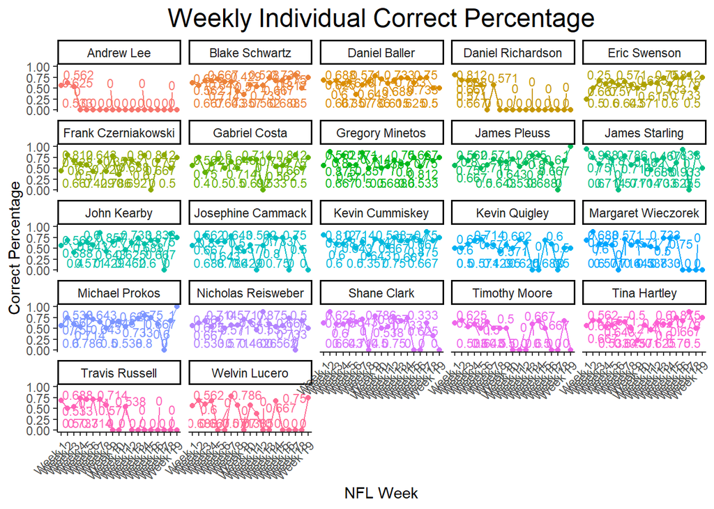

## MA206 Group Predictions

This Week's MA206 Predictions

Week 19

| Game | Prediction | Winner | Correct | Correct Votes | Correct Percent |
| --- | --- | --- | --- | --- | --- |
| 1 | Green Bay Packers | Green Bay Packers | Yes | 4 | 1.00 |
| 2 | Buffalo Bills | Buffalo Bills | Yes | 3 | 0.75 |
| 3 | Kansas City Chiefs | Kansas City Chiefs | Yes | 4 | 1.00 |
| 4 | New Orleans Saints | Tampa Bay Buccaneers | No | 0 | 0.00 |

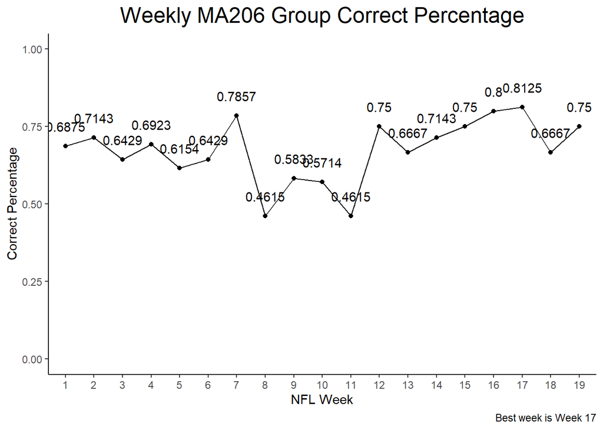